# Advanced Research Dataset Homeworks

# Dataset 3 - ANCOVA & MANOVA

### 1. A psychologist who is interested in aggression has devised an experimental paradigm in which participants play a computer game with an opponent. When the opponent makes an error the participant is invited to “punish” their opponent by exposing him to a blast of loud noise. The duration and volume of the noise blast are combined to give a measure of aggression. A total of 60 participants were tested using this procedure before being given feedback about their performance in the game. One third of the participants received negative feedback, one third received positive feedback and the remaining third received neutral feedback. Finally, the participants played the game again and their level of aggression was measured as before. The data from this study can be found in the file Ex10Q1.sav.

```r
Ex10Q1 <- read_sav("Ex10Q1.sav")
str(Ex10Q1)
```

```
## Classes 'tbl_df', 'tbl' and 'data.frame':    62 obs. of  4 variables:
##  $ Part_Num : num  1 2 3 4 5 6 7 8 9 10 ...
##   ..- attr(*, "format.spss")= chr "F8.0"
##  $ Condition: 'haven_labelled' num  1 1 1 1 1 1 1 1 1 1 ...
##   ..- attr(*, "format.spss")= chr "F8.0"
##   ..- attr(*, "display_width")= int 10
##   ..- attr(*, "labels")= Named num  1 2 3
##   .. ..- attr(*, "names")= chr  "Positive Interaction" "Neutral Intraction" "Negative Interaction"
##  $ Pre_test : num  133 114 126 133 118 ...
##   ..- attr(*, "format.spss")= chr "F8.2"
##  $ Post_Test: num  80 114.1 99 119.8 97.1 ...
##   ..- attr(*, "format.spss")= chr "F8.2"
```

### 1.a. Undertake an ANOVA to determine whether the post-feedback levels of aggression are affected by feedback.

Fit ANOVA

```r
aov.fit6 <- aov(Post_Test ~ as.factor(Condition), data = Ex10Q1)
summary(aov.fit6)
```

```
##                      Df Sum Sq Mean Sq F value Pr(>F)
## as.factor(Condition)  2   3510  1755.0   3.881 0.0263 *
## Residuals            57  25777   452.2
## ---
## Signif. codes:  0 '***' 0.001 '**' 0.01 '*' 0.05 '.' 0.1 ' ' 1
## 2 observations deleted due to missingness
```

Post-test levels of aggression are affected by feedback.

### 1.b. Participants were randomly assigned to each of the three feedback conditions, and as a result the pre-test scores for these three groups should not differ. Test whether this is the case.

Test the pre-test for differences

```r
summary(aov(Pre_test ~ as.factor(Condition), data = Ex10Q1))
```

```
##                      Df Sum Sq Mean Sq F value  Pr(>F)
## as.factor(Condition)  2   2700  1350.0    5.59 0.00607 **
## Residuals            57  13765   241.5
## ---
## Signif. codes:  0 '***' 0.001 '**' 0.01 '*' 0.05 '.' 0.1 ' ' 1
## 2 observations deleted due to missingness
```

```r
#nope - problem!
```

There is clearly a difference in the pretest.

### 1.c. In light of the answer to the previous question, use the pre-test scores as a covariate and re-examine the effect of feedback on aggression.

To run the ANCOVA, include the “covariant” variable(s) `Pre_test` *in front* of the IV in the formula.

```r
summary(aov(Post_Test ~ Pre_test + as.factor(Condition), data = Ex10Q1))
```

```
##                      Df Sum Sq Mean Sq F value Pr(>F)
## Pre_test              1   2087  2086.7   4.686 0.0347 *
## as.factor(Condition)  2   2263  1131.3   2.540 0.0879 .
## Residuals            56  24938   445.3
## ---
## Signif. codes:  0 '***' 0.001 '**' 0.01 '*' 0.05 '.' 0.1 ' ' 1
## 2 observations deleted due to missingness
```

This shows that when the `Pre_test` is included in the formula, the main effect for `Condition` is not significant.

Option 2 - create a gain score - subtract pre_test scores from post_test.

```r
Ex10Q1$gain <- Ex10Q1$Post_Test - Ex10Q1$Pre_test
#create new variable gain score

summary(aov(gain ~ as.factor(Condition), data = Ex10Q1))
```

```
##                      Df Sum Sq Mean Sq F value  Pr(>F)
## as.factor(Condition)  2  11136    5568   6.849 0.00216 **
## Residuals            57  46340     813
## ---
## Signif. codes:  0 '***' 0.001 '**' 0.01 '*' 0.05 '.' 0.1 ' ' 1
## 2 observations deleted due to missingness
```

```r
#run one-way ANOVA
```

### 1.d. How does the inclusion of pre-test aggression as a covariate change the outcome of the analysis?

```r
TukeyHSD(aov(Post_Test ~ as.factor(Condition) * Pre_test, data = Ex10Q1))
```

```
##   Tukey multiple comparisons of means
##     95% family-wise confidence level
##
## Fit: aov(formula = Post_Test ~ as.factor(Condition) * Pre_test, data = Ex10Q1)
##
## $`as.factor(Condition)`
##          diff        lwr       upr     p adj
## 2-1 18.534264   2.566008 34.502520 0.0192146
## 3-1 11.635607  -4.332649 27.603863 0.1941648
## 3-2 -6.898657 -22.866913  9.069599 0.5544382
```

### 1.e. What should the psychologist conclude regarding the effect of feedback on aggression?

The psychologist should conclude that *some* of the difference in the `post_test` is essentially accounted for in the `pre_test`. Additionally, the kind of feedback has an effect on aggression. The biggest, and only significant, difference is noted between “positive” and “neutral” feedback.

### 2. Geiselman and colleagues 1 developed the Cognitive Interview (CI) to help police officers obtain accurate information from witnesses. Research has demonstrated that the use of the CI results in an increase in recall for the details of an event, however, there is less evidence that the CI results in more accurate descriptions of the people involved in the event. A psychologist has developed a new interview, which she calls the “Visual Interview” (VI) which is specifically designed to help witness describe the people they saw. A group of 20 participants watched a video of two actors performing a number of actions. After a delay of 24 hours the participants were interviewed using the CI or the VI. Each participant’s description of the actions was scored out of 100 and their description of the appearance of the actors was scored out of 60. The data are contained in file Ex10Q2.sav.

```r
Ex10q2 <- read_sav("Ex10q2.sav")
head(Ex10q2)
```

| Part_Number | Interview | Memory_Events | Memory_People |
| --- | --- | --- | --- |
| 1 | 1 | 80.91960 | 42.54190 |
| 2 | 1 | 56.73844 | 31.02768 |
| 3 | 1 | 62.30000 | 13.40172 |
| 4 | 1 | 41.00000 | 19.96736 |
| 5 | 1 | 70.43300 | 20.18599 |
| 6 | 1 | 43.63821 | 30.04314 |

### 2.a. Describe the design of this study

2x2 mixed design

### 2.b. Check your data to determine whether it is appropriate for analysis using MANOVA.

Test data to ensure it is appropriate.

Correlations are checked between the dependent variables to check for correlations above .8, which can be problematic:

```r
#Pearson's product-moment correlation
cor.test(Ex10q2$Memory_Events,Ex10q2$Memory_People)
```

```
##
##  Pearson's product-moment correlation
##
## data:  Ex10q2$Memory_Events and Ex10q2$Memory_People
## t = 1.0762, df = 18, p-value = 0.2961
## alternative hypothesis: true correlation is not equal to 0
## 95 percent confidence interval:
##  -0.220663  0.620839
## sample estimates:
##       cor
## 0.2458661
```

```r
#0.24 - no problem found
```

Test for normality:

```r
#Shapiro-Wilk test
shapiro.test(Ex10q2$Memory_Events)
```

```
##
##  Shapiro-Wilk normality test
##
## data:  Ex10q2$Memory_Events
## W = 0.97122, p-value = 0.7804
```

```r
#normal
shapiro.test(Ex10q2$Memory_People)
```

```
##
##  Shapiro-Wilk normality test
##
## data:  Ex10q2$Memory_People
## W = 0.98082, p-value = 0.9443
```

```r
#normal
leveneTest(Ex10q2$Memory_People, as.factor(Ex10q2$Interview))
```

|  | Df | F value | Pr(>F) |
| --- | --- | --- | --- |
| group | 1 | 0.5007687 | 0.4882248 |
|  | 18 | NA | NA |

```r
leveneTest(Ex10q2$Memory_Events, as.factor(Ex10q2$Interview))
```

|  | Df | F value | Pr(>F) |
| --- | --- | --- | --- |
| group | 1 | 0.02030231 | 0.8882788 |
|  | 18 | NA | NA |

```r
#homogeneity of variance
```

Data is appropriate.

### 2.c. The psychologists hypothesised that the VI would result in better memory for the appearance of the actors, but that there would be no difference between the VI and CI groups for recall of the events. She predicted that this relationship would hold for both short and long delays. Analyse the data to test these hypotheses.

There are no observations provided in this dataset for delay.

### 2.d. Assuming these results are reliable, what are the implications with regard to how police should interview witnesses?

Fit the model:

```r
manova.fit <- manova(as.matrix(Ex10q2)[,3:4] ~ Ex10q2$Interview)
manova.fit
```

```
## Call:
##    manova(as.matrix(Ex10q2)[, 3:4] ~ Ex10q2$Interview)
##
## Terms:
##                 Ex10q2$Interview Residuals
## Memory_Events             87.726  3757.102
## Memory_People            447.720  1145.321
## Deg. of Freedom                1        18
##
## Residual standard errors: 14.44742 7.976775
## Estimated effects may be unbalanced
```

```r
summary(manova.fit, test = "Pillai")
```

```
##                  Df  Pillai approx F num Df den Df  Pr(>F)
## Ex10q2$Interview  1 0.36533   4.8927      2     17 0.02097 *
## Residuals        18
## ---
## Signif. codes:  0 '***' 0.001 '**' 0.01 '*' 0.05 '.' 0.1 ' ' 1
```

```r
#Pillai's Trace is the most robust test
summary(aov(Memory_Events ~ Interview, Ex10q2))
```

```
##             Df Sum Sq Mean Sq F value Pr(>F)
## Interview    1     88   87.73    0.42  0.525
## Residuals   18   3757  208.73
```

```r
#not sig
summary(aov(Memory_People ~ Interview, Ex10q2))
```

```
##             Df Sum Sq Mean Sq F value Pr(>F)
## Interview    1  447.7   447.7   7.036 0.0162 *
## Residuals   18 1145.3    63.6
## ---
## Signif. codes:  0 '***' 0.001 '**' 0.01 '*' 0.05 '.' 0.1 ' ' 1
```

```r
#significant
eta_sq(aov(Memory_People ~ Interview, Ex10q2),partial = T, ci.lvl = 0.95)
```

| term | partial.etasq | conf.low | conf.high |
| --- | --- | --- | --- |
| Interview | 0.2810476 | 0.009267931 | 0.5313915 |

```r
#effect size and confidence intervals
```

Assumptions of homogeneity of variance-covariance matrices and equality of variance were confirmed, and small correlations were found among the dependent variables. There was a significant difference between the two interview types, $F$(2,17) = 4.892, $p$ = .021, Pillai’s Trace = .365. Analyses of the independent variables (Bonferroni adjusted $\alpha$ = `.05/2`), showed that the ‘memory events’ condition did not significantly differ between interviews $F$(1,18) = 0.42, $p$ = .525. Significant differences in interview were found for the ‘memory people’ condition $F$(1,18) = 7.04, $p$ = .016. Individuals who had the Cognitive Interview (CI) had a lower mean score on ‘memory people’ condition ($M$ = 28.6) than the individuals who had the Visual Interview (VI) ($M$ = 38.1). There was a large effect size, $\eta_p^2$ = .281, 95% CI [0.009, 0.531].

Police should use the Visual Interview (VI) to interview witnesses about people given that there is a statistically significant difference of approximately 9.5 points in accuracy.

# Dataset 4 - Correlation

### These exercises have been prepared for use in conjunction with Chapter 6 of the 5th edition of “SPSS for Psychologists” by Brace, Kemp and Snelgar (2012). This exercise uses the data file Employee data.sav which we corrected as part of Exercise 5. Load the corrected file now

### 1. Is there any evidence of a correlation between starting salary and current salary? What is the magnitude and direction of the correlation and is it statistically significant? What does this tell us?

Correlation between starting and current salary

```r
head(Employee_data)
```

| id | gender | bdate | educ | jobcat | salary | salbegin | jobtime | prevexp | minority |
| --- | --- | --- | --- | --- | --- | --- | --- | --- | --- |
| 1 | 2 | 1952-02-03 | 15 | 3 | 57000 | 27000 | 98 | 144 | 0 |
| 2 | 2 | 1958-05-23 | 16 | 1 | 40200 | 18750 | 98 | 36 | 0 |
| 3 | 1 | 1929-07-26 | 12 | 1 | 21450 | 12000 | 98 | 381 | 0 |
| 4 | 1 | 1947-04-15 | 8 | 1 | 21900 | 13200 | 98 | 190 | 0 |
| 5 | 2 | 1955-02-09 | 15 | 1 | 45000 | 21000 | 98 | 138 | 0 |
| 6 | 2 | 1958-08-22 | 15 | 1 | 32100 | 13500 | 98 | 67 | 0 |

```r
cor.test(Employee_data$salbegin, Employee_data$salary)
```

```
##
##  Pearson's product-moment correlation
##
## data:  Employee_data$salbegin and Employee_data$salary
## t = 40.276, df = 472, p-value < 2.2e-16
## alternative hypothesis: true correlation is not equal to 0
## 95 percent confidence interval:
##  0.8580696 0.8989267
## sample estimates:
##       cor
## 0.8801175
```

This relationship is highly correlated and significant (r = .88, N = 474, $p$ < .001).

### 2. Draw a scattergram to illustrate the relationship between starting salary and current salary. Add a regression line to the scattergram.

“Scatterplot”

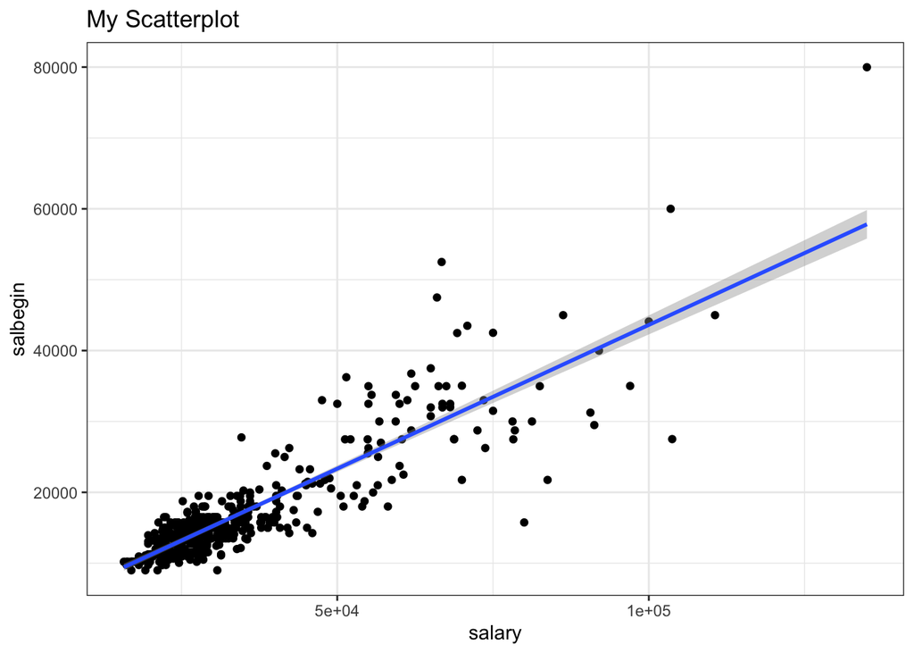

```r
Employee_data%>%
  dplyr::select(salbegin,salary)%>%
  ggplot(aes(x = salary , y = salbegin)) + geom_point() +
  geom_smooth(method = "lm") + theme_bw() + ggtitle("My Scatterplot")
```

### 3. What percentage of the variance in current salary is explained by starting salary?

Percentage of variance (regression)

```r
summary(lm(salbegin~salary, data = Employee_data))
```

```
##
## Call:
## lm(formula = salbegin ~ salary, data = Employee_data)
##
## Residuals:
## <Labelled double>: Beginning Salary
##      Min       1Q   Median       3Q      Max
## -19756.7  -1604.1    -61.8   1277.9  22368.4
##
## Labels:
##  value   label
##      0 missing
##
## Coefficients:
##              Estimate Std. Error t value Pr(>|t|)
## (Intercept) 3.053e+03  3.869e+02   7.891 2.11e-14 ***
## salary      4.057e-01  1.007e-02  40.276  < 2e-16 ***
## ---
## Signif. codes:  0 '***' 0.001 '**' 0.01 '*' 0.05 '.' 0.1 ' ' 1
##
## Residual standard error: 3741 on 472 degrees of freedom
## Multiple R-squared:  0.7746, Adjusted R-squared:  0.7741
## F-statistic:  1622 on 1 and 472 DF,  p-value: < 2.2e-16
```

Approximately 77% of the variance ($F$(1, 472) = 1622, $p$ < .001).

### 4. Produce a correlation matrix showing the correlations between the following variables: beginning salary, current salary, time in the job, previous experience.

Correlation matrix

```r
cor(Employee_data[,6:9]) #accomplished with subsetting [ ]
```

```
##               salary    salbegin      jobtime      prevexp
## salary    1.00000000  0.88011747  0.084092267 -0.097466926
## salbegin  0.88011747  1.00000000 -0.019753475  0.045135627
## jobtime   0.08409227 -0.01975347  1.000000000  0.002978134
## prevexp  -0.09746693  0.04513563  0.002978134  1.000000000
```

### 5. Examine the correlation matrix and identify which of these correlations are statistically significant.

Significant correlations

```r
cor.test(Employee_data$prevexp,Employee_data$salary) #yes
```

```
##
##  Pearson's product-moment correlation
##
## data:  Employee_data$prevexp and Employee_data$salary
## t = -2.1277, df = 472, p-value = 0.03388
## alternative hypothesis: true correlation is not equal to 0
## 95 percent confidence interval:
##  -0.185900660 -0.007466824
## sample estimates:
##         cor
## -0.09746693
```

```r
cor.test(Employee_data$jobtime,Employee_data$salary) #no (p = .07)
```

```
##
##  Pearson's product-moment correlation
##
## data:  Employee_data$jobtime and Employee_data$salary
## t = 1.8334, df = 472, p-value = 0.06737
## alternative hypothesis: true correlation is not equal to 0
## 95 percent confidence interval:
##  -0.006018969  0.172848789
## sample estimates:
##        cor
## 0.08409227
```

### 6. Which two variables are significantly negatively correlated? Can you suggest possible reasons for this relationship?

There is a weak, but significant, negative correlation is between previous experience and current salary (r = -.1, $p$ = .03). Maybe previous experience led to some bad habits that are holding people back?

### 7. An organisational Psychologist wants to know whether there is a relationship between education and current salary. What is the most appropriate statistical test to use for this analysis? Justify your answer. Is the correlation significant?

Relationship between education and current salary.

```r
gvlma(lm(educ ~ salary, data = Employee_data)) #assumptions not acceptable for skewness
```

```
##
## Call:
## lm(formula = educ ~ salary, data = Employee_data)
##
## Coefficients:
## (Intercept)       salary
##   9.6504036    0.0001116
##
##
## ASSESSMENT OF THE LINEAR MODEL ASSUMPTIONS
## USING THE GLOBAL TEST ON 4 DEGREES-OF-FREEDOM:
## Level of Significance =  0.05
##
## Call:
##  gvlma(x = lm(educ ~ salary, data = Employee_data))
##
##                      Value   p-value                   Decision
## Global Stat        84.1150 0.000e+00 Assumptions NOT satisfied!
## Skewness           35.0813 3.162e-09 Assumptions NOT satisfied!
## Kurtosis            0.3246 5.688e-01    Assumptions acceptable.
## Link Function      47.9918 4.280e-12 Assumptions NOT satisfied!
## Heteroscedasticity  0.7173 3.970e-01    Assumptions acceptable.
```

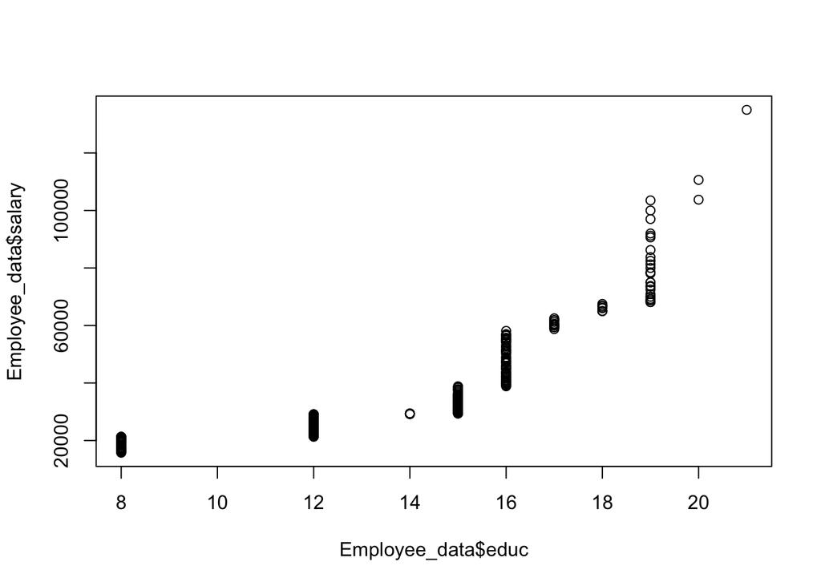

```r
qqplot(Employee_data$educ,Employee_data$salary) #also seen in q-q plot
```

The best statistical test is Spearman’s Rho - the data is not continuous, nor normally distributed.

```r
cor.test(Employee_data$educ,Employee_data$salary, method = "spearman")
```

```
##
##  Spearman's rank correlation rho
##
## data:  Employee_data$educ and Employee_data$salary
## S = 5529541, p-value < 2.2e-16
## alternative hypothesis: true rho is not equal to 0
## sample estimates:
##       rho
## 0.6884647
```

# Dataset 5 - Binary Logistic Regression

### These exercises have been prepared for use in conjunction with Chapter 11 of the 5th edition of “SPSS for Psychologists” by Brace, Kemp and Snelgar (2012)

### 1. A psychologist is interested in how radiographers learn to interpret ambiguous x-ray images. He recruited a number of trainee radiographers. Each was shown an x-ray and asked to determine whether or not it showed a fracture. The psychologist recorded the number of hours of training the radiographer had completed, whether the x-ray showed a fracture or not, and whether the radiographer’s decision was correct. The data from this study are coded in the file Ex11Q1.sav.

### 1.a. Identify the outcome and predictor variables. Which of the predictor variables are categorical?

```r
head(logdata)
```

| Radiog_ID | Training | X_ray | correct |
| --- | --- | --- | --- |
| 1 | 2 | 1 | 0 |
| 5 | 2 | 1 | 0 |
| 24 | 2 | 1 | 0 |
| 25 | 4 | 0 | 0 |
| 28 | 4 | 0 | 0 |
| 33 | 5 | 1 | 0 |

```r
logdata$Training
```

```
##  [1]  2  2  2  4  4  5  5  6  6  6  6  7  7  8  8  8 10 12 12  1  2  2  3
## [24]  3  3  3  4  4  4  5  5  6  6 12 14
## attr(,"label")
## [1] "N of months in training"
## attr(,"format.spss")
## [1] "F8.2"
```

```r
#predictor - cont.
logdata$X_ray
```

```
## <Labelled double>: Does x-ray show fracture
##  [1] 1 1 1 0 0 1 0 1 1 1 0 0 1 0 0 1 1 1 0 0 0 0 1 0 0 0 1 0 1 1 0 0 1 0 1
##
## Labels:
##  value       label
##      0 no fracture
##      1    Fracture
```

```r
#predictor - cat.

logdata$correct
```

```
## <Labelled double>: Was decision correct
##  [1] 0 0 0 0 0 0 0 1 0 1 0 1 1 1 1 1 1 1 1 0 0 0 0 0 0 0 0 0 0 1 0 1 1 1 1
##
## Labels:
##  value   label
##      0   Wrong
##      1 Correct
```

```r
#outcome - cat.
```

### 1.b. Carry out the appropriate analysis to determine which of the predictor variables significantly predict the radiographer’s interpretation of the x-ray.

```r
model <- glm(correct ~ Training, data = logdata, family = "binomial")
summary(model) #z value is "Wald"
```

```
##
## Call:
## glm(formula = correct ~ Training, family = "binomial", data = logdata)
##
## Deviance Residuals:
##      Min        1Q    Median        3Q       Max
## -1.57737  -0.19249  -0.01683   0.07825   1.86132
##
## Coefficients:
##             Estimate Std. Error z value Pr(>|z|)
## (Intercept)  -13.746      6.102  -2.253   0.0243 *
## Training       2.442      1.073   2.275   0.0229 *
## ---
## Signif. codes:  0 '***' 0.001 '**' 0.01 '*' 0.05 '.' 0.1 ' ' 1
##
## (Dispersion parameter for binomial family taken to be 1)
##
##     Null deviance: 47.804  on 34  degrees of freedom
## Residual deviance: 12.685  on 33  degrees of freedom
## AIC: 16.685
##
## Number of Fisher Scoring iterations: 8
```

```r
lrm(model) # "Model Likelihood Ratio" to get X^2 results
```

```
## Logistic Regression Model
##
##  lrm(formula = model)
##
##                        Model Likelihood     Discrimination    Rank Discrim.
##                           Ratio Test           Indexes           Indexes
##  Obs            35    LR chi2      35.12    R2       0.850    C       0.975
##   0             20    d.f.             1    g        8.798    Dxy     0.950
##   1             15    Pr(> chi2) <0.0001    gr    6620.359    gamma   0.986
##  max |deriv| 9e-05                          gp       0.480    tau-a   0.479
##                                             Brier    0.061
##
##            Coef     S.E.   Wald Z Pr(>|Z|)
##  Intercept -13.7454 6.1018 -2.25  0.0243
##  Training    2.4416 1.0732  2.28  0.0229
##
```

```r
confusion_matrix(model) #to produce confusion matrix
```

```
##          Predicted 0 Predicted 1 Total
## Actual 0          18           2    20
## Actual 1           1          14    15
## Total             19          16    35
```

```r
18/20 #percentage hit for correct
```

```
## [1] 0.9
```

```r
14/15 #percentage hit for incorrect
```

```
## [1] 0.9333333
```

```r
(18/20 + 14/15)/2 #0.916 overall accuracy
```

```
## [1] 0.9166667
```

```r
confint(model) #to get confidence intervals
```

```
##                   2.5 %    97.5 %
## (Intercept) -31.4286241 -5.639071
## Training      0.9946912  5.479247
```

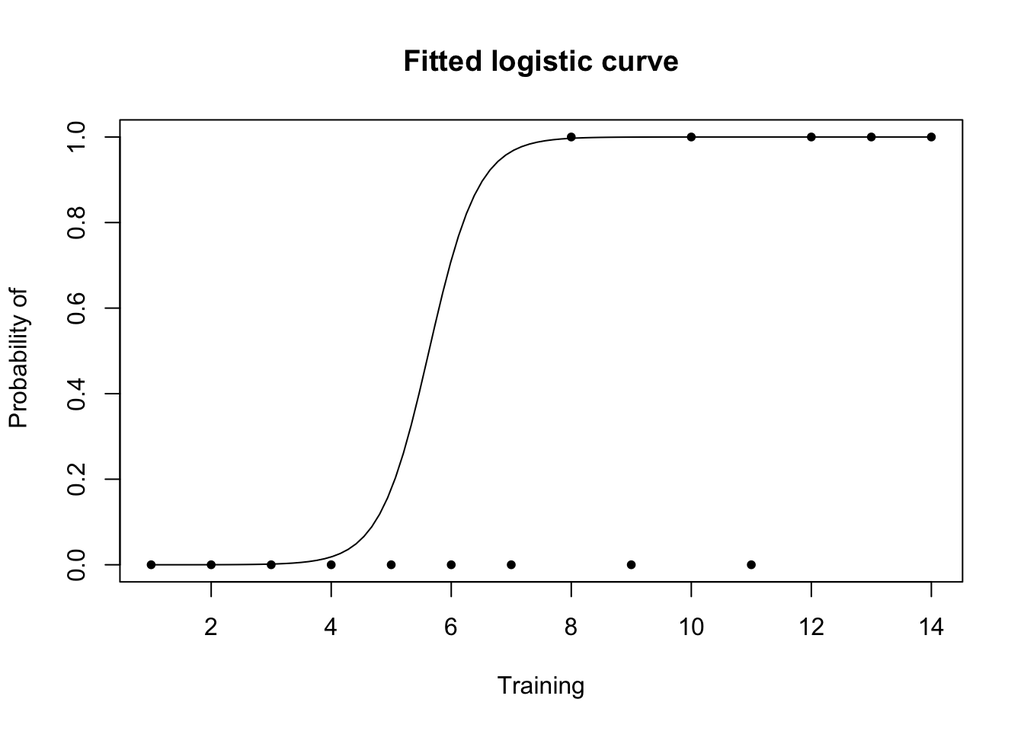

Visualization of Logistic Regression Model

```r
visualize_model(model) #plot the model
points(logdata$correct, pch=20) #put in the points
```

### 2. Load the data file called EX11Q2.sav. This is a demonstration data file which for many years was supplied with every copy of SPSS (and called ‘1991 U.S. General Social Survey.sav’) but is not with recent versions. Open the data file and familiarise yourself with the variables. This file contains more than 40 variables for each of about 1500 respondents.

### 2.a We are interested in which factors predict happiness. The fourth variable in the file is called “Happy” and codes the respondents’ general level of happiness using a 3 point scale (1=Very Happy, 2= Pretty Happy, 3=Not too Happy), with the values 0, 8 and 9 set as missing values. Recode this variable so that it codes whether or not the respondent is Very Happy (Very Happy= 1, Pretty Happy or Not too Happy = 0). Make sure that that the missing values are still set to 0, 8 and 9.

```r
any(logdata2[,"happy"] == 8)|any(logdata2[,"happy"] == 0)|any(logdata2[,"happy"] == 9)
```

```
## [1] NA
```

```r
#confirmed NA's

logdata2$recode <- rep(NA, length(logdata2$happy))
ncol(logdata2)
```

```
## [1] 44
```

```r
logdata2[which(logdata2$happy == 1),44] <- 1
logdata2[which(logdata2$happy == 2|logdata2$happy == 3),44] <- 0

head(as.vector(logdata2$recode),20)
```

```
##  [1]  1  0  1 NA  0  0  1  0  0  0  0  1  0  0  0  1  0  1  0  1
```

### 2.b. Is the secret to being very happy having a large family, a good education or is happiness something that comes with age? To discover the secret to happiness undertake a Binary Logistic regression using the four variables age, education, number of siblings and number of children as predictor variables, and your recoded happiness variable as the dependent variable.

```r
model2 <- glm(recode ~ childs + age + educ + sibs, data = logdata2, family = "binomial")
summary(model2) #z value is "Wald"
```

```
##
## Call:
## glm(formula = recode ~ childs + age + educ + sibs, family = "binomial",
##     data = logdata2)
##
## Deviance Residuals:
##     Min       1Q   Median       3Q      Max
## -1.2761  -0.8808  -0.7849   1.3870   1.9863
##
## Coefficients:
##              Estimate Std. Error z value Pr(>|z|)
## (Intercept) -2.730493   0.369745  -7.385 1.53e-13 ***
## childs       0.047252   0.035229   1.341  0.17983
## age          0.009030   0.003456   2.613  0.00899 **
## educ         0.104631   0.020862   5.015 5.29e-07 ***
## sibs         0.019167   0.019445   0.986  0.32429
## ---
## Signif. codes:  0 '***' 0.001 '**' 0.01 '*' 0.05 '.' 0.1 ' ' 1
##
## (Dispersion parameter for binomial family taken to be 1)
##
##     Null deviance: 1843.8  on 1483  degrees of freedom
## Residual deviance: 1813.2  on 1479  degrees of freedom
##   (33 observations deleted due to missingness)
## AIC: 1823.2
##
## Number of Fisher Scoring iterations: 4
```

```r
lrm(model2) # "Model Likelihood Ratio" to get X^2 results
```

```
## Frequencies of Missing Values Due to Each Variable
## recode childs    age   educ   sibs
##     13      8      3      7     12
##
## Logistic Regression Model
##
##  lrm(formula = model2)
##
##
##                        Model Likelihood     Discrimination    Rank Discrim.
##                           Ratio Test           Indexes           Indexes
##  Obs          1484    LR chi2      30.61    R2       0.029    C       0.588
##   0           1020    d.f.             4    g        0.350    Dxy     0.177
##   1            464    Pr(> chi2) <0.0001    gr       1.420    gamma   0.177
##  max |deriv| 1e-12                          gp       0.074    tau-a   0.076
##                                             Brier    0.210
##
##            Coef    S.E.   Wald Z Pr(>|Z|)
##  Intercept -2.7305 0.3697 -7.38  <0.0001
##  childs     0.0473 0.0352  1.34  0.1798
##  age        0.0090 0.0035  2.61  0.0090
##  educ       0.1046 0.0209  5.02  <0.0001
##  sibs       0.0192 0.0194  0.99  0.3243
##
```

### 2.c. Which of these factors significantly predict Happiness?

Age and education.

### 2.d. Does your model really hold the secret of great happiness? Just how good a model is it?

```r
confusion_matrix(model2) #to produce confusion matrix
```

```
##          Predicted 0 Predicted 1 Total
## Actual 0        1013           7  1020
## Actual 1         458           6   464
## Total           1471          13  1484
```

```r
1013/1020 #percentage hit for unhappy
```

```
## [1] 0.9931373
```

```r
6/464 #percentage hit for happy
```

```
## [1] 0.01293103
```

```r
(1013/1020 + 6/464)/2 #0.50 overall accuracy
```

```
## [1] 0.5030341
```

```r
confint(model2) #to get confidence intervals
```

```
##                    2.5 %      97.5 %
## (Intercept) -3.461938383 -2.01167804
## childs      -0.022049324  0.11618262
## age          0.002243123  0.01580178
## educ         0.063990281  0.14582307
## sibs        -0.019282422  0.05707391
```

# Dataset 6 - Factor Analysis

These exercises have been prepared for use in conjunction with Chapter 12 of the 5th edition of “SPSS for Psychologists” by Brace, Kemp and Snelgar (2012)

### 1. A psychologist was interested in whether a mindfulness questionnaire measured a single dimension, or whether it had more than one dimension. The data from this study are recorded in the file Ex12.sav. The questionnaire contained 15 items each requiring a response in the range 1 to 6. The responses are coded in the variables s1q1 to s1q15.

### 1.a. Carry out a principal component analysis with direct oblimin rotation.

```r
which(is.na(Ex12)) #found missing data = problem
```

```
## [1]  358 1107
```

```r
#rectify
pcdata <- na.omit(Ex12)
head(pcdata)
```

| s1q1 | s1q2 | s1q3 | s1q4 | s1q5 | s1q6 | s1q7 | s1q8 | s1q9 | s1q10 | s1q11 | s1q12 | s1q13 | s1q14 | s1q15 |
| --- | --- | --- | --- | --- | --- | --- | --- | --- | --- | --- | --- | --- | --- | --- |
| 1 | 1 | 1 | 2 | 5 | 5 | 1 | 6 | 4 | 6 | 1 | 1 | 1 | 1 | 5 |
| 3 | 3 | 4 | 5 | 3 | 4 | 4 | 4 | 5 | 4 | 3 | 5 | 4 | 5 | 5 |
| 6 | 1 | 5 | 1 | 5 | 6 | 2 | 6 | 2 | 2 | 6 | 6 | 5 | 2 | 5 |
| 3 | 3 | 3 | 2 | 3 | 4 | 3 | 3 | 4 | 3 | 2 | 5 | 4 | 2 | 3 |
| 3 | 1 | 3 | 2 | 5 | 1 | 5 | 6 | 5 | 6 | 3 | 6 | 2 | 5 | 6 |
| 3 | 4 | 4 | 5 | 3 | 5 | 4 | 5 | 5 | 5 | 5 | 4 | 3 | 6 | 5 |

```r
#done

#fit the model
(pca <- psych::pca(pcdata, rotate = "oblimin"))
```

```
## Principal Components Analysis
## Call: principal(r = r, nfactors = nfactors, residuals = residuals,
##     rotate = rotate, n.obs = n.obs, covar = covar, scores = scores,
##     missing = missing, impute = impute, oblique.scores = oblique.scores,
##     method = method)
## Standardized loadings (pattern matrix) based upon correlation matrix
##        PC1   h2   u2 com
## s1q1  0.44 0.19 0.81   1
## s1q2  0.47 0.22 0.78   1
## s1q3  0.63 0.39 0.61   1
## s1q4  0.45 0.21 0.79   1
## s1q5  0.39 0.15 0.85   1
## s1q6  0.45 0.20 0.80   1
## s1q7  0.77 0.59 0.41   1
## s1q8  0.75 0.57 0.43   1
## s1q9  0.68 0.46 0.54   1
## s1q10 0.69 0.47 0.53   1
## s1q11 0.53 0.28 0.72   1
## s1q12 0.76 0.57 0.43   1
## s1q13 0.48 0.23 0.77   1
## s1q14 0.79 0.62 0.38   1
## s1q15 0.64 0.40 0.60   1
##
##                 PC1
## SS loadings    5.56
## Proportion Var 0.37
##
## Mean item complexity =  1
## Test of the hypothesis that 1 component is sufficient.
##
## The root mean square of the residuals (RMSR) is  0.09
##  with the empirical chi square  142.03  with prob <  0.00039
##
## Fit based upon off diagonal values = 0.94
```

```r
#here I have to specify psych:: package because sjstats 'masks' pca function
summary(pca)
```

```
##
## Factor analysis with Call: principal(r = r, nfactors = nfactors, residuals = residuals,
##     rotate = rotate, n.obs = n.obs, covar = covar, scores = scores,
##     missing = missing, impute = impute, oblique.scores = oblique.scores,
##     method = method)
##
## Test of the hypothesis that 1 factor is sufficient.
## The degrees of freedom for the model is 90  and the objective function was  1.39
## The number of observations was  93  with Chi Square =  119.15  with prob <  0.022
##
## The root mean square of the residuals (RMSA) is  0.09
```

### 1.b. State as many of the indicators of factorability as you can. For each, check and report what they indicate about the factorability of this data set. NB for those without a test of significance, simply give an impression; as in the book, you don’t need to give counts.

??? Need more information about the data.

### 1.c. How many components have eigenvalue greater than one? Write a brief results section, with suitable table, to report which items load on each component.

```r
mat <- cor(pcdata)

eigen(mat)$values
```

```
##  [1] 5.5612434 1.3507022 1.1770218 0.9870781 0.9272446 0.7725799 0.7172660
##  [8] 0.6616967 0.5837894 0.5725700 0.4418724 0.3689357 0.3483938 0.3203822
## [15] 0.2092238
```

```r
#The first three components have an Eigenvalue greater than 1.
```

### 1.d. Consider the scree plot: how many components does that suggest?

Scree Plot

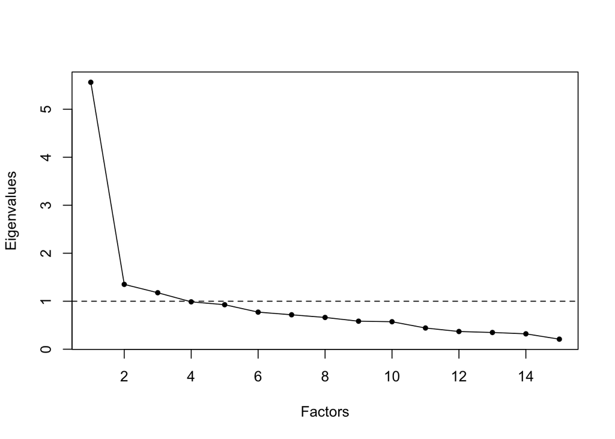

Scree Plot

```r
plot(eigen(mat)$values, type = "l", ylab = "Eigenvalues",
     xlab = "Factors")
points(eigen(mat)$values, pch = 20)
abline(h = 1, lty = 2)
```

The biggest “drop-off” takes place between factors 1 and 2. I would not retain more than one factor. This is confirmed by `1.f.`

### 1.e. How would you alter the analysis to assess which items load onto a single component? Do that, and report the results.

??? Alter the analysis? Why?

### 1.f. What other analysis/es might you conduct when considering the questionnaire?

Alternative methods - none in SPSS.

```r
factanal(pcdata, factors = 1)
```

```
##
## Call:
## factanal(x = pcdata, factors = 1)
##
## Uniquenesses:
##  s1q1  s1q2  s1q3  s1q4  s1q5  s1q6  s1q7  s1q8  s1q9 s1q10 s1q11 s1q12
## 0.835 0.820 0.655 0.828 0.881 0.843 0.448 0.482 0.563 0.566 0.777 0.464
## s1q13 s1q14 s1q15
## 0.828 0.402 0.639
##
## Loadings:
##       Factor1
## s1q1  0.406
## s1q2  0.424
## s1q3  0.587
## s1q4  0.415
## s1q5  0.345
## s1q6  0.396
## s1q7  0.743
## s1q8  0.720
## s1q9  0.661
## s1q10 0.659
## s1q11 0.472
## s1q12 0.732
## s1q13 0.415
## s1q14 0.773
## s1q15 0.601
##
##                Factor1
## SS loadings      4.970
## Proportion Var   0.331
##
## Test of the hypothesis that 1 factor is sufficient.
## The chi square statistic is 115.49 on 90 degrees of freedom.
## The p-value is 0.0364
```

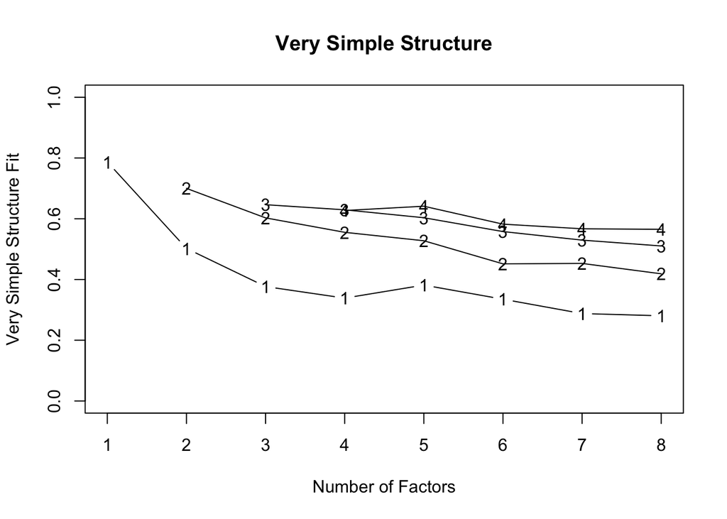

```
##
## Very Simple Structure
## Call: vss(x = pcdata, rotate = "oblimin")
## VSS complexity 1 achieves a maximimum of 0.79  with  1  factors
## VSS complexity 2 achieves a maximimum of 0.7  with  2  factors
##
## The Velicer MAP achieves a minimum of 0.02  with  1  factors
## BIC achieves a minimum of  -292.26  with  1  factors
## Sample Size adjusted BIC achieves a minimum of  -23.48  with  4  factors
##
## Statistics by number of factors
##   vss1 vss2   map dof chisq  prob sqresid  fit  RMSEA  BIC SABIC complex
## 1 0.79 0.00 0.019  90   116 0.035     8.3 0.79 0.0645 -292  -8.2     1.0
## 2 0.50 0.70 0.024  76    87 0.187    11.6 0.70 0.0509 -258 -17.8     1.4
## 3 0.38 0.60 0.029  63    65 0.392    13.7 0.65 0.0384 -220 -21.2     1.5
## 4 0.34 0.56 0.040  51    47 0.645    14.5 0.63 0.0097 -184 -23.5     1.9
## 5 0.38 0.53 0.048  40    32 0.796    13.7 0.65 0.0000 -149 -22.6     1.8
## 6 0.34 0.45 0.064  30    25 0.738    14.7 0.62 0.0000 -111 -16.5     1.9
## 7 0.29 0.45 0.086  21    18 0.635    14.7 0.62 0.0000  -77 -10.7     2.2
## 8 0.28 0.42 0.116  13    12 0.568    16.7 0.57 0.0092  -47  -6.4     2.0
##   eChisq  SRMR eCRMS eBIC
## 1  106.6 0.074 0.080 -301
## 2   66.0 0.058 0.068 -279
## 3   40.7 0.046 0.059 -245
## 4   27.4 0.037 0.054 -204
## 5   15.0 0.028 0.045 -166
## 6   10.3 0.023 0.043 -126
## 7    6.5 0.018 0.041  -89
## 8    4.2 0.015 0.042  -55
```

```r
#this is part of the base r stats package and confirms the prior "pca" test

vss(pcdata, rotate = "oblimin")
```

```r
#VSS stands for Very Simple Structure, which is a method included in the `psych` package.
#It provides a plot depicting the "factors" and explicitly states what complexity is achieved
#with what number of factors.

paran(pcdata, iterations = 5000)
```

```
##
## Using eigendecomposition of correlation matrix.
## Computing: 10%  20%  30%  40%  50%  60%  70%  80%  90%  100%
##
##
## Results of Horn's Parallel Analysis for component retention
## 5000 iterations, using the mean estimate
##
## --------------------------------------------------
## Component   Adjusted    Unadjusted    Estimated
##             Eigenvalue  Eigenvalue    Bias
## --------------------------------------------------
## 1           4.805884    5.561243      0.755359
## --------------------------------------------------
##
## Adjusted eigenvalues > 1 indicate dimensions to retain.
## (1 components retained)
```

```r
#This method is by far the most robust - it follows Horn's Parallel Analysis and employs
#bootstrapping (shown here with 5000 iterations).
```

[^1]: Cohen’s $f$ = `sqrt(.79/(1-.79))`; to make sure my scientific notation skills are on par -> 1.198907e-07 < .001 = TRUE